# Coursework Report

*N* removed NAs: 2

*N* removed typo: 1

*N* removed <18: 22

*N* total clean: 125

| Group | *N* | *M*<sub>age</sub> | *M*<sub>rating</sub> |
| --- | --- | --- | --- |
| Control | 60 | 20.18 | 5.66 |
| Experim | 65 | 20.82 | 6.34 |

**Main analysis results**

*t*(123) = -4.34, *p* < .001

[interactive chart not shown]

[figure not shown]

[interactive chart not shown]

# Coursework Report

Analysing Data, Spring 2020

# Methods

## Participants

The table below shows a summary of descpritives by experimental condition, of the participants information:

*Figure 1.* Descriptive statistics of Age by Condition

| CONDITION | *N* | % | *M*<sub>age</sub> | *SD*<sub>age</sub> | *Min*<sub>age</sub> | *Max*<sub>age</sub> |
| --- | --- | --- | --- | --- | --- | --- |
| control | 60 | 48 | 20.18 | 1.85 | 18 | 28 |
| experimental | 65 | 52 | 20.82 | 1.74 | 18 | 24 |

## Design

The area of research of this study, was to observe whether colour was in anyway influential to how women perceive men’s attractiveness. Our experiment comprised of two groups, where the categories consisted of a red(experimental) and a white(control) condition. We included an independent categorical measure for colour as our participants either saw one or the other condition, and they were not interchanged between both groups.

Since colour was what we were manipulating throughout the experiment, it is the predictor variable. Consequently, the measure of attractiveness was our continuous variable. To measure the extent of attractiveness, a likert scale ranging from 1(not attractive at all) to 9(very attractive) was used. Operationalisation of these variables were carried out by presenting the participants with three questions and recording each of their ratings. The questions asked were: “How attractive do you think this person is?,“How pleasant is this person to look at?, and “If you were to meet this person in public, would you think he is attractive?”

Operational hypothesis: Does viewing an image of a moderately attractive man with a different background colour, change the mean ratings of the man’s attractiveness?

To investigate if there is a significant difference in mean ratings of attractiveness between the two groups, we will be conducting an independent measure *t*-test to compare the means.

# Results

*Figure 2.* Descriptive statisctics of Condition by Score

| CONDITION | *M*<sub>score</sub> | *SD* | *Min*<sub>score</sub> | *Max*<sub>score</sub> | *Range* |
| --- | --- | --- | --- | --- | --- |
| control | 5.66 | 0.81 | 3.67 | 7.33 | 3.67 |
| experimental | 6.34 | 0.93 | 4.00 | 8.67 | 4.67 |

Below shows the means of attracitiveness ratings of both groups presented graphically, with the confidence intervals around each mean:

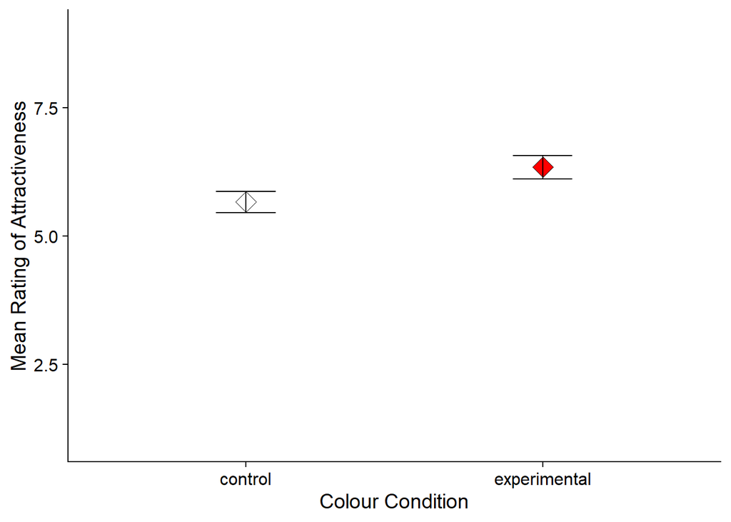

*Figure 3.* Mean Attractiveness Rating in Both Conditons

# Discussion

Red has a history of commonly being associated with women across cultures to enhance their perceived attractiveness in men(Lin, 2014). Our study was designed to replicate experiment 1 found in the paper of Elliot et al., to do the opposite; to determine if a woman’s attraction to the image of a man is influenced based on the colour the man is associated with(Elliot et al., 2010). Our data supports the findings of this paper and as a result, provides more evidence supporting the research question, as the image of the man was considered more desirable for women when placed in front of the colour red. This statement is derived from the results of our *t*-test, where it revealed that there was a significantly larger mean value in the red group as opposed to the white group, allowing us to reject the null hypothesis.

For further support of the ‘red effect’ mentioned by Elliot et al., our sample size consisted of more participants compared to Elliot et al.’s study, yet, our results still confirmed there to be a significant difference between the two groups. Another key aspect that was identified was that red primarily functions as a sexual signal and it did not predict overall likability of the man based on his other qualities. Our findings are unable to comment on this, as we exclusively analysed the relationship of the measure of attraction, not sexual attraction or status position(Elliot et al., 2010). Possible reasons for this observed ‘red effect’ could be rooted down to the biological importance of different pigmentations of red on the skin. Greater redness observed on the face or body of either sex, suggests the concept that the flushed appearance is considered to relate to a healthier individual. This, being due to their blood consisting of a higher proportion of oxygenated blood(Re et al., 2011). This could subconsciously play a role during the search for a partner. This phenomenon can more easily be observed in rhesus macaque. Female rhesus macaque innately tends to choose males with a darker face for mating, as they seem healthier and more fit to support their offspring in the long-term. It’s worth mentioning that the use of colourful ornaments is prominent in birds but rare in mammals(Dubuc et al., 2014). This lays a greater dependence on specifically female’s choice of mate selection, as it will play a crucial role on the future population of their species.

There had been other studies that followed the same design and method as Elliot et al.’s experiment 1, to determine if the results were reproducible, but these studies have found no statistical difference on the colour red and attractiveness (Hesslinger et al., 2015). Subsequently, researchers were quick to pick up on the trend of flawlessly executed experiments found in the Elliot et al. study, that resulted in most of them rejecting their null hypothesis. This caused a few to hint that the study itself was tainted with publication bias(Francis, 2013). This undoubtedly raises ecological validity in the execution of the research question within Elliot et al.’s study. It is important to keep in mind that this could solely affect our conclusion, as we replicated one of their experiments using the same method and design. There are also instances in other studies, where even whilst executing a similar experiment with a larger sample size (just like our study) than our study, it still resulted in no significant effect of red on attractiveness(Elliot & Maier, 2013).

Our principle aim was to test the reliability of the research question by viewing just one predictor variable – colour of the background of an image, to see if there was any notable effect on ratings of attractiveness. This limits the opportunities to relay our findings to a real-world setting. Introducing the colour red on different mediums such as on the body, items or on clothing either whilst in a stationary or in a moving(real-time) condition (Peperkoorn et al., 2016), may be able to explain our research question in more depth. Additionally, as mentioned above, we were only able to identify whether women were attracted to men superficially. Our results do not extend to cover the ground on making statements on women’s overall likeability of the man, based on the colour red. To improve this aspect of the study, future studies could incorporate the method of allowing participants to have short discussions with the man placed in front of a red background and measure the women’s liking of the other qualities of the man. This is to see whether red enhances the man’s other personal characteristics. Interestingly, the colour black is known to be a sister, competing colour to red for measures of attractiveness. Black is associated with increased likeability in fashion between both genders. Future studies may also benefit from exploring this area, by comparing the differences in the alluring nature of both colours between genders(Pazda et al., 2014).

In summary, the results from our sample does provide support on attractiveness judgement based on colour. Although, the experiment of the paper that we were replicating is deemed controversial, and this might be due to their sample size, design and method. Future replication studies intending to focus on this paper, should take this factor into account while doing so, and appropriately amend aspects of their execution.

# References

Dubuc, C., Allen, W. L., Maestripieri, D., & Higham, J. P. (2014). Is male rhesus macaque red color ornamentation attractive to females? Behavioral Ecology and Sociobiology, 68(7), 1215–1224. https://doi.org/10.1007/s00265-014-1732-9

Elliot, A. J., & Maier, M. A. (2013). The red-attractiveness effect, applying the Ioannidis and Trikalinos (2007b) test, and the broader scientific context: A reply to Francis (2013) - ProQuest. https://search.proquest.com/docview/1285624501?accountid=14182

Elliot, A. J., Niesta Kayser, D., Greitemeyer, T., Lichtenfeld, S., Gramzow, R. H., Maier, M. A., & Liu, H. (2010). Red, rank, and romance in women viewing men. *Journal of Experimental Psychology: General, 139*(3), 399–417. https://doi.org/10.1037/a0019689

Francis, G. (2013). Publication bias in “Red, rank, and romance in women viewing men,” by Elliot et al. (2010). Journal of Experimental Psychology: General, 142(1), 292–296. https://doi.org/10.1037/a0027923

Lin, H. (2014). Red-colored products enhance the attractiveness of women. Displays, 35(4), 202–205. https://doi.org/10.1016/j.displa.2014.05.009

Pazda, A. D., Elliot, A. J., & Greitemeyer, T. (2014). Perceived sexual receptivity and fashionableness: Separate paths linking red and black to perceived attractiveness. Color Research & Application, 39(2), 208–212. https://doi.org/10.1002/col.21804

Peperkoorn, L. S., Roberts, S. C., & Pollet, T. V. (2016). Revisiting the Red Effect on Attractiveness and Sexual Receptivity: No Effect of the Color Red on Human Mate Preferences. Evolutionary Psychology, 14(4), 1474704916673841. https://doi.org/10.1177/1474704916673841

Re, D. E., Whitehead, R. D., Xiao, D., & Perrett, D. I. (2011). Oxygenated-Blood Colour Change Thresholds for Perceived Facial Redness, Health, and Attractiveness. PLoS ONE, 6(3). https://doi.org/10.1371/journal.pone.0017859